# Question

A standard-form quadratic function has three parameters $a$, $b$, and $c$:

$$y=ax^2+bx+c$$

When graphed, the quadratic function represents a parabola with a vertical axis of symmetry. The quadratic coefficient, $a$, represents the vertical stretch and orientation (whether the parabola opens upwards or downwards).

- If $a<0$, the parabola opens downwards, and the vertex is a maximum.
- If $a>0$, the parabola opens upwards, and the vertex is a minimum.

The constant term, $c$, represents the $y$-intercept. The linear coefficient, $b$, does not have a simple geometric interpretation. However, it is an essential part of some key formulas. For example, we have formulas for finding the vertex at $(h,k)$:

$$h=\frac{-b}{2a}$$

$$k=\frac{4ac-b^2}{4a}$$

Another important quantity we can calculate is the [discriminant](https://en.wikipedia.org/wiki/Quadratic_equation#Discriminant).

$$D~=~b^2-4ac$$

- If $D<0$, there are 0 $x$-intercepts.
- If $D=0$, there is 1 $x$-intercept, the vertex.
- If $D>0$, there are 2 $x$-intercepts.

A parabolic curve is defined with a quadratic function in standard form.

$$y~=~{7}x^{2}-{13}x-{5}$$

- What is the parabola’s orientation?
- ##ANSWER1##
- Calculate $D$, the discriminant.
- ##ANSWER2##
- How many $x$-intercepts does the curve have?
- ##ANSWER3##
- Is the vertex left or right of the $y$ axis?
- ##ANSWER4##
- Is the vertex above or below the $x$ axis?
- ##ANSWER5##

## Answerlist

- The parabola opens downward.
- The parabola opens upward.`
- -309
- -29
- 0
- 29
- 309
- There are 0 x-intercepts
- There is 1 x-intercept
- There are 2 x-intercepts
- The vertex is to the left of the y axis.
- The vertex is on the y axis.
- The vertex is to the right of the y axis.
- The vertex is below the x axis.
- The vertex is on the x axis.
- The vertex is above the x axis.

# Solution

Identify the coefficients.

$$a=7$$
$$b=-13$$
$$c=-5$$

### Orientation

The quadratic coefficient, $a=7$, is positive, so the parabola opens upward.

### Discriminant and number of roots

$$D=(-13)^2-4(7)(-5)$$

$$D=309$$

The discriminant, $D=309$, is positive, so there are two $x$-intercepts.

### Vertex position

$$h=\frac{-(-13)}{2(7)}$$

$$h=0.9285714$$

The horizontal coordinate of the vertex, $h=0.928571428571429$, is positive, so the vertex is to the right of the y axis.

$$k=\frac{4(7)(-5)-(-13)^2}{4(7)}$$

$$k=-11.0357143$$

The vertical coordinate of the vertex, $k=-11.0357142857143$, is negative, so the vertex is below of the x axis.

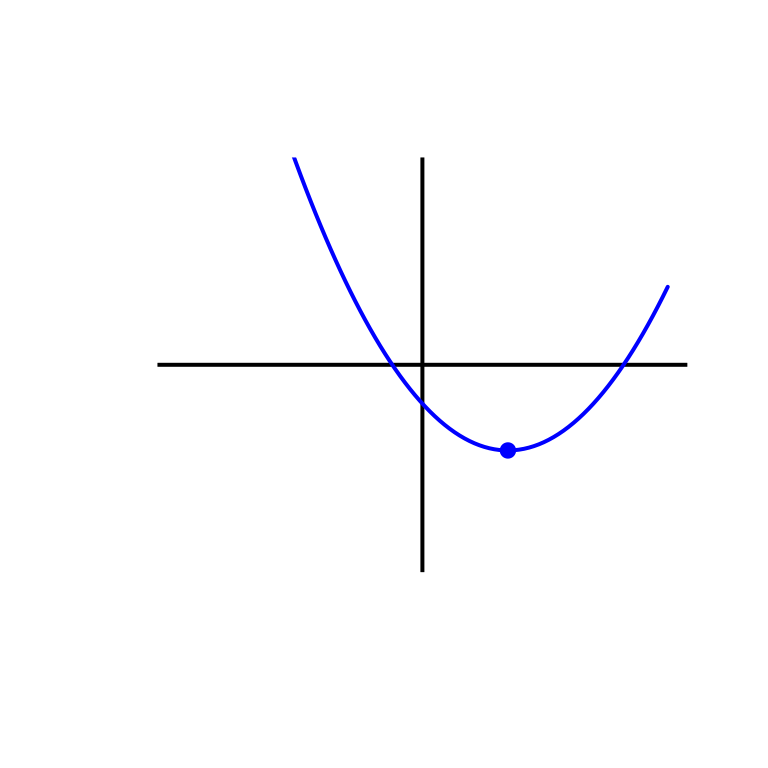

# Meta-information

extype: cloze exclozetype: schoice|schoice|schoice|schoice|schoice exsolution: 01|00001|001|001|100 exname: discriminant_num_roots